# Lecture Notes - Probability & Distributions of Random Variables

Curry W. Hilton

# Basic Probability

#### Experiment:

An activity or process whose outcome possesses uncertainty

#### Sample Space:

Set of all possible outcomes of an experiment ($\delta$)

#### Event:

A collection of outcomes contained in the sample space

### Dice Roll

- *Experiment*: Roll a dice one time and record the outcome
- *Sample Space*:
- *Events*: {6}, {An even number}, {A number divisible by 2}

### Coin Toss

- *Experiment*: Flip a coin three times and record the outcomes (No order necessary)
- *Sample Space*:
- *Events*: {H, H, H}, {H, T, T}, {H, T, H}

### Set Theory

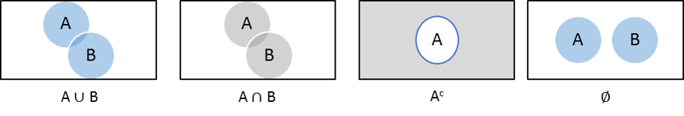

#### Union:

$A \cup B$ “A or B” An event consisting of all outcomes in either A or in B or in both

#### Intersection:

$A \cap B$ “A and B” An event consisting of all outcomes that are in both A and B

#### Complement:

$A^{c}$ Set all outcomes in the $\delta$ that are not contained in A

#### Disjoint or Mutually Exclusive:

$\emptyset$ “Null event” $A \cap B = \emptyset$

### Example

Let $A=${0, 1, 2, 3, 4}, $B=${3, 4, 5, 6}, and $C$={1, 3, 5}. Assume the $\delta$ = {0, 1, 2, 3, 4, 5, 6}

- $A^{c} =$
- $A \cup B =$
- $A \cap B =$
- $A \cap C =$
- $(A \cap C)^{c} =$

### Probability & A Few Properties

A probability measure or probability $P$ is an assignment of a real number $P(A)$ to each event $A$ in $\delta$ that satisfies the following axioms:

1. $P(\emptyset)=0$
2. $P(\delta) = 1$
3. $0 \leq P(A) \leq 1$
4. If events $A$ and $B$ are *disjoint* then $A \cap B = \emptyset$ and $P(A \cup B) = P(A) + P(B)$

For any event $A$:

- $P(A) + P(A^{c})=1$
- $P(A) \leq 1$

For any two events $A$ and $B$:

- $P(A \cup B) = P(A)+P(B)-P(A \cap B)$

**In basic terms…probability is a measure of how likely an event will occur, where the closer the probability is to zero the less likely the event will occur and the closer the probability is to one the more likely the event will occur.**

# Distributions of Random Variables

## Discrete Probability Distributions

### Binomial Probability Distribution

#### Conditions

1. Experiment consists of subset experiments, trials $(n)$ where $n$ is fixed before the experiment occurs
2. Each trial results in a binary outcome, success $(S)$ or failure $(F)$
3. Each trial is independent
4. Probability of $P(S)$ is constant among trials

### Binomial Random Variable X

$X$ = the number of successes among the $n$ trials

### Distribution

$$b(x; n, p) = {n \choose x}p^x(1-p)^{n-x}$$

Where, $x$ = number of successes from 0 to $\infty$ in discrete movements; $n$ = number of trials; $p$ = the probability of success

*Note*: ${n \choose x} = \frac{n!}{x!(n-x)!}$

**Mean**: $E[X] = np$

**Variance**: $Var[X] = np(1-p)$

### R - Binomial

```r
dbinom(x, size, prob, log = FALSE)                         # probability according to random value, x
pbinom(q, size, prob, lower.tail = TRUE, log.p = FALSE)    # probability according to quantile (cumulative)
qbinom(p, size, prob, lower.tail = TRUE, log.p = FALSE)    # quantile according to probability
rbinom(n, size, prob)                                      # random selection

# x = value of random value, x
# q = quantile (x)
# p = probability
# n = number of random generations
# size = number of observations in experiment
# prob = probability of event occurring
```

*Note* lower.tail => $P[X \leq x]$, otherwise, $P[X>x]$

### Example

Each of six randomly selected cola drinkers is given a glass containing cola S and one containing cola F. The glasses are identical in appearance except for a code on the bottom to identify the cola. Suppose there is actually no tendency among cola drinkers to prefer one cola to the other. The p = P(a selected individual prefers S) = 0.5, so with X = the number among the six who prefer S, X ~ Binomial(6, 0.5).

1. What is the probability that exactly three individuals prefer S?

```r
dbinom(3, 6, 0.5)
```

```
## [1] 0.3125
```

2. What is the probability that at least three prefer S?

```r
pbinom(2, 6, 0.5, lower.tail = FALSE)
```

```
## [1] 0.65625
```

3. What is the mean and variance of the distribution given the parameters?

```r
n <- 6
p <- 0.5
mean <- n*p
mean
```

```
## [1] 3
```

```r
variance <- n*p*(1-p)
variance
```

```
## [1] 1.5
```

### Hypergeometric Probability Distribution

#### Conditions

1. Each trial is *not* independent
2. Probability of $P(S)$ is *not* constant among trials
3. Sampling *without* replacement

### Hypergeometric Random Variable X

$X$ = the number of successes among the $n$ trials

### Distribution

*Note*: ${n \choose x} = \frac{n!}{x!(n-x)!}$

**Mean**: $E[X] = \frac{nm}{N}$

**Variance**: $Var[X] = n (\frac{m}{N}) (1-\frac{m}{N}) (\frac{N-n}{N-1})$

### R - Hypergeometric

```r
dhyper(x, m, n, k, log = FALSE)                        # probability according to random value, x
phyper(q, m, n, k, lower.tail = TRUE, log.p = FALSE)   # probability according to quantile (cumulative)
qhyper(p, m, n, k, lower.tail = TRUE, log.p = FALSE)   # quantile according to probability
rhyper(nn, m, n, k)                                    # random selection

# x = value of random value, x
# q = quantile (x)
# m = number of successes
# n = number of failures
# k = number of trials
# nn = number of random generations
```

### Example

In a standard deck of cards (52 cards), 4 aces exist. Suppose you draw 3 cards out of the deck *without* replacement.

1. What is the probability that of the three cards selected two are aces?

```r
dhyper(2, 4, 48, 3)
```

```
## [1] 0.01303167
```

2. What is the probability that at least one of the cards is an ace?

```r
phyper(0, 4, 48, 3, lower.tail = FALSE)
```

```
## [1] 0.2173756
```

### Geometric Probability Distribution

#### Conditions

1. Each trial is independent
2. Probability of $P(S)$ is constant among trials

### Geometric Random Variable X

$X$ = the number of trials on which the first success occurs

### Distribution

$$g(x; p) = (1-p)^{x-1}p$$

Where, $x$ = number of trials on which the first success occurs; $p$ = the probability of success on each trial

**Mean**: $E[X] = \frac{1}{p}$

**Variance**: $Var[X] = \frac{(1-p)}{p^2}$

### R - Geometric

```r
dgeom(x, prob, log = FALSE)                       # probability according to random value, x
pgeom(q, prob, lower.tail = TRUE, log.p = FALSE)  # probability according to quantile (cumulative)
qgeom(p, prob, lower.tail = TRUE, log.p = FALSE)  # quantile according to probability
rgeom(n, prob)                                    # random selection

# x = number of failures until first success, x
# q = quantile (x)
# p = probability
# n = number of observations
# k = number of trials
# prob = probability of event occurring
```

### Example

Tanner is known for his mad beer pong skills (https://en.wikipedia.org/wiki/Beer_pong). Over multiple years he has reﬁned the art and only misses the cup 10% of the time when “shooting”. Assume each shot is independent of the next and the previous.

1. What is the probability that his 3rd shot is a miss?

```r
dgeom(2, 0.1)
```

```
## [1] 0.081
```

2. On average how many times will Tanner “make” the shot in a row before he misses?

```r
p <- 0.1
mean <- 1/p
mean
```

```
## [1] 10
```

### Poisson Probability Distribution

#### Conditions

1. Probability of occurence is constant among all intervals
2. Independence among occurrence among all intervals

### Poisson Random Variable X

$X$ = the number of occurrences of a relatively rare phenomenom in a fixed interval of time or space

### Distribution

$$po(x; \lambda) = \frac{e^{-\lambda} \lambda^x}{x!}$$

Where, $x$ = number of occurrences of a relatively rare phenomenom in a fixed interval of time or space; $e$ = 2.718128, $\lambda$ = expected value of occurrences in an interval

**Mean**: $E[X] = \lambda$

**Variance**: $Var[X] = \lambda$

### R - Poisson

```r
dpois(x, lambda, log = FALSE)                        # probability according to random value, x
ppois(q, lambda, lower.tail = TRUE, log.p = FALSE)   # probability according to quantile (cumulative)
qpois(p, lambda, lower.tail = TRUE, log.p = FALSE)   # quantile according to probability
rpois(n, lambda)                                     # random selection

# x = number of events occurrring within a certain interval, x
# q = quantile (x)
# p = probability
# lambda = expected value of occurrences in an interval
```

### Example

At the verizon call center, phone calls from disgruntled customers are received at roughly 50 per hour.

1. What is the probability of receiving three calls in a 5-minute interval?

```r
dpois(3, lambda = ((50/60)*5))
```

```
## [1] 0.1869195
```

2. What is the probability of receiving no calls in a 1-minute interval?

```r
dpois(0, lambda = ((50/60)))
```

```
## [1] 0.4345982
```

### Other Common Discrete Probability Distributions

1. Negative Binomial
2. Uniform

## Continuous Probability Distributions

### Uniform Probability Distribution

### Distribution

$$Uniform(a, b) = \frac{1}{b-a}$$

Where, $a$ = the left hand interval; $b$ = the right hand interval

[figure not shown]

**Mean**: $E[X] = \frac{b+a}{2}$

**Variance**: $Var[X] = \frac{(b-a)^2}{12}$

### R - Uniform

```r
dunif(x, min = 0, max = 1, log = FALSE)                       # probability according to random value, x
punif(q, min = 0, max = 1, lower.tail = TRUE, log.p = FALSE)  # probability according to quantile (cumulative)
qunif(p, min = 0, max = 1, lower.tail = TRUE, log.p = FALSE)  # quantile according to probability
runif(n, min = 0, max = 1)                                    # random selection

# x = number, x
# q = quantile (x)
# p = probability
# n = number of observations
# min
# max
```

### Example

Southwest airlines passenger planes travel from Birmingham, AL to Raleigh, NC on a time schedule that is considered distributed uniformly between 120 minutes and 160 minutes.

1. What is the probability that the duration of the plane trip is shorter than 142 minutes?

```r
punif(142, min = 120, max = 160)
```

```
## [1] 0.55
```

2. What is the expected duration of any given plane trip?

```r
min <- 120
max <- 160
mean <- (min+max)/2
mean
```

```
## [1] 140
```

### Normal Probability Distribution

A continuous random variable $X$ is said to be normally distributed with parameters $\mu$ and $\sigma$ where $-\infty < \mu < \infty$ and $\sigma >0$

## Distribution

$$f(x;\mu, \sigma) = \frac{1}{\sqrt{2\pi}\sigma}e^{\frac{-(x-\mu)^2}{2\sigma^2}}$$

Where, $-\infty < x < \infty$

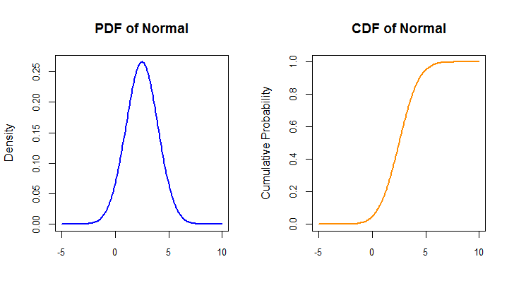

```r
x <- seq(-5, 10, 0.1)
plot(x,dnorm(x,2.5,1.5),type="l",col="blue",xlab="",
     ylab="Density", lwd=2, cex=2, main="PDF of Normal", cex.axis=.8)
plot(x, cumulative<-pnorm(x, 2.5, 1.5), col="darkorange", xlab="",
     ylab="Cumulative Probability",type="l",lwd=2, cex=2, main="CDF of Normal",
     cex.axis=.8)
```

- The function **pnorm(x, $\mu$, $\sigma$)** computes the proportion of observations in the normal distribution that are less than or equal to x; that is $P(X \leq x)$, where X is N($\mu$, $\sigma$).
- The function **pnorm(x, $\mu$, $\sigma$, lower.tail = FALSE)** computes the proportion of observations in the normal distribution that are greater than or equal to x; that is $P(X \geq x)$, where X is N($\mu$, $\sigma$).

### Example:

$$\mu = 50$$
$$\sigma = 5$$

What is the probability that the random variable X is less than 49 | less than or equal to 49 (Asking the same question since distribution is continuous)?

```r
pnorm(49, 50, 5)
```

```
## [1] 0.4207403
```

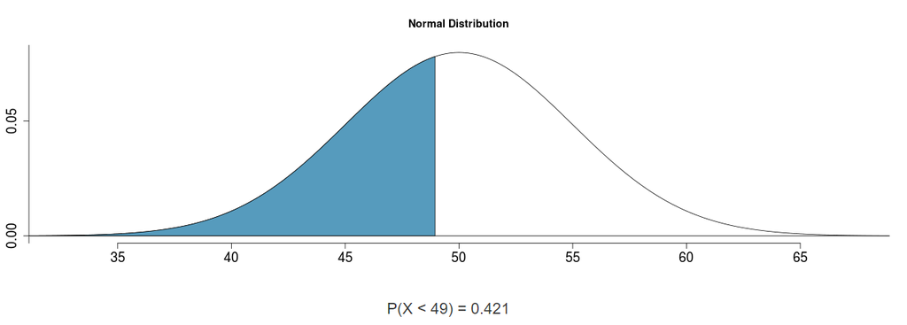

What is the probability that the random variable X is greater than or equal to 56?

```r
pnorm(56, 50, 5, lower.tail = FALSE)
```

```
## [1] 0.1150697
```

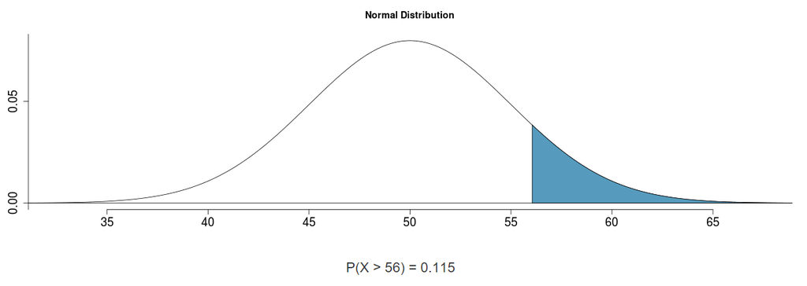

What is the probability that the random variable X is in between 46 and 56?

```r
pnorm(56, 50, 5) - pnorm(46, 50, 5)
```

```
## [1] 0.6730749
```

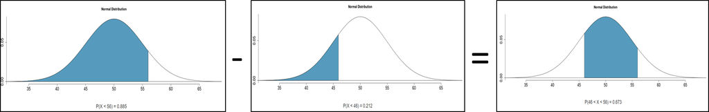

# Standardizing Random Variables

$$z = \frac{x-\mu}{\sigma}$$

## Standard Normal Distribution

Where, $-\infty < z < \infty$

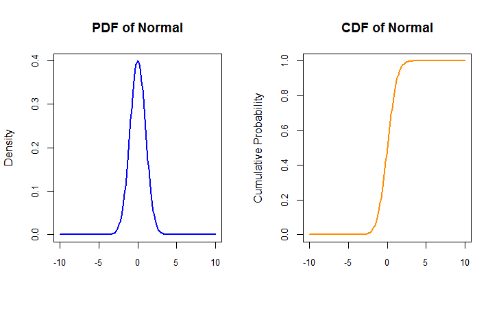

```r
x <- seq(-10, 10, 0.1)
plot(x,dnorm(x,0,1),type="l",col="blue",xlab="",
     ylab="Density", lwd=2, cex=2, main="PDF of Normal", cex.axis=.8)
plot(x, cumulative<-pnorm(x, 0, 1), col="darkorange", xlab="",
     ylab="Cumulative Probability",type="l",lwd=2, cex=2, main="CDF of Normal",
     cex.axis=.8)
```

## Parallel Normal - Standard Normal

### Example

$$\mu = 5$$
$$\sigma = 1$$

What is the probability that the random variable X is below 6?

- Normal Approach with Normal Distribution, $X \sim N(\mu = 5, \sigma = 1)$:

```r
pnorm(6, 5, 1)
```

```
## [1] 0.8413447
```

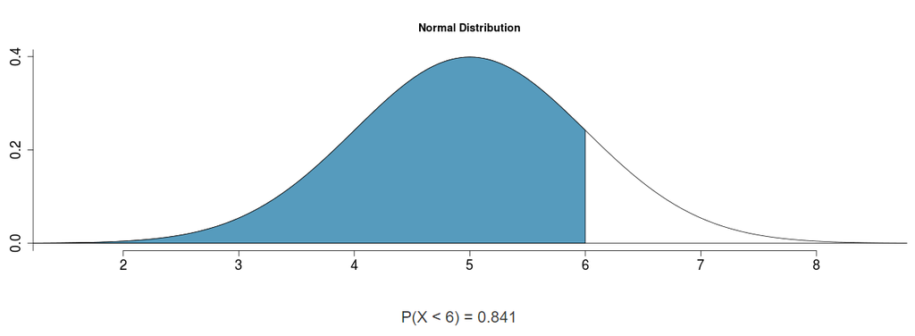

- Standardized Approach with Standard Normal Distribution, $X \sim N_s(\mu = 0, \sigma = 1)$:

$$z = \frac{x-\mu}{\sigma}$$
$$z = \frac{6-5}{1} = 1$$

```r
pnorm(1, 0, 1)
```

```
## [1] 0.8413447
```

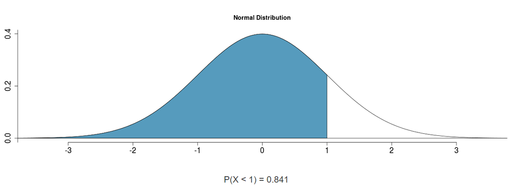

### 68-95-99.7 Rule

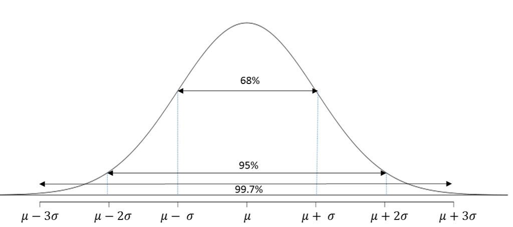

## Inverse Normal Derivation

$$z = \frac{x-\mu}{\sigma}$$
$$z\sigma = x - \mu$$
$$x = z\sigma + \mu$$

The R function **qnorm(p, $\mu$, $\sigma$)** returns the quantile where there is a probability of $p$ of getting a value less than or equal to it. Basically, the quantile represents the value of $x$ that $P(X\leq x)=p$, where $p$ is given.

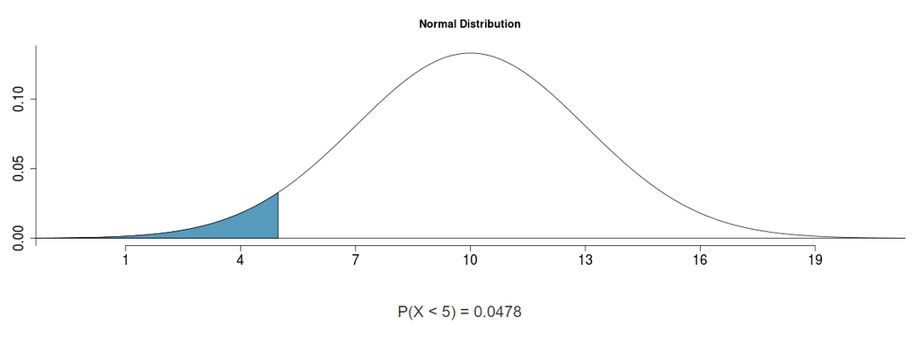

### Example

$$\mu = 15$$
$$\sigma^2 = 25$$
$$p = 0.274$$

What is the value of the quantile (value of $x$) associated with the given $p$, which measures the probability to the left of the unknown quantile?

```r
qnorm(0.274, 15, 5)
```

```
## [1] 11.9962
```

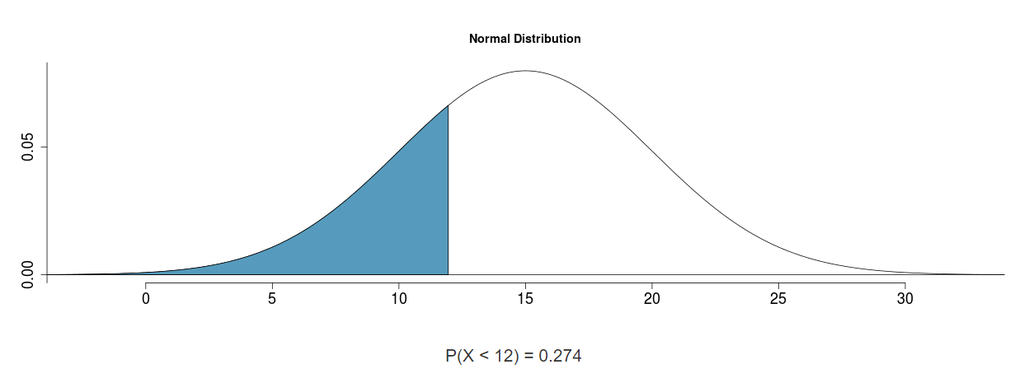

*Standardizing Approach*

```r
qnorm(0.274, 0, 1)
```

```
## [1] -0.6007598
```

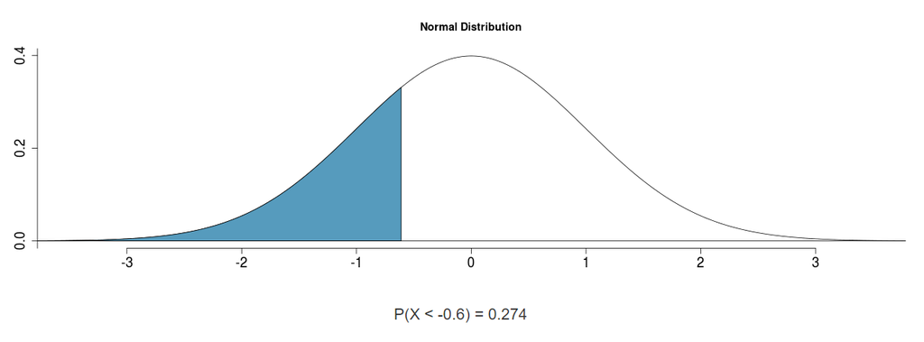

### R - Normal

```r
pnorm(q, mean = 0, sd = 1, lower.tail = TRUE, log.p = FALSE)  # probability according to quantile (cumulative)
qnorm(p, mean = 0, sd = 1, lower.tail = TRUE, log.p = FALSE)  # quantile according to probability
rnorm(n, mean = 0, sd = 1)                                    # random selection

# x = number, x
# q = quantile (x)
# p = probability
# n = number of observations
# mean = mean of the normal distribution
# sd = standard deviation of the normal distribution
```

### Example

The yield strength (ksi) for A36 grade steel is normally distributed with $\mu$ = 21 and $\sigma$ = 4

1. What is the probability that yield strength is at most 27?

```r
pnorm(27, mean = 21, sd = 4)
```

```
## [1] 0.9331928
```

2. What is the probability that yield strength is greater than 34?

```r
pnorm(34, mean = 21, sd = 4, lower.tail = FALSE)
```

```
## [1] 0.000577025
```

3. What is the probability that yield strength is between 18 and 25?

```r
pnorm(25, mean = 21, sd = 4) - pnorm(18, mean = 21, sd = 4)
```

```
## [1] 0.6147174
```

```r
qnorm(0.75, mean = 21, sd =4)
```

```
## [1] 23.69796
```

5. What is the probability that yield strength is 31?

```r
# Not able to calcualte
```

### Exponential Probability Distribution

### Distribution

$$Exp(x) = \frac{1}{\beta}e^{\frac{-x}{\beta}}$$

Where, $x$ = time between events or time required for an activity; $\beta$ = expected value or mean; $e$ = 2.718128

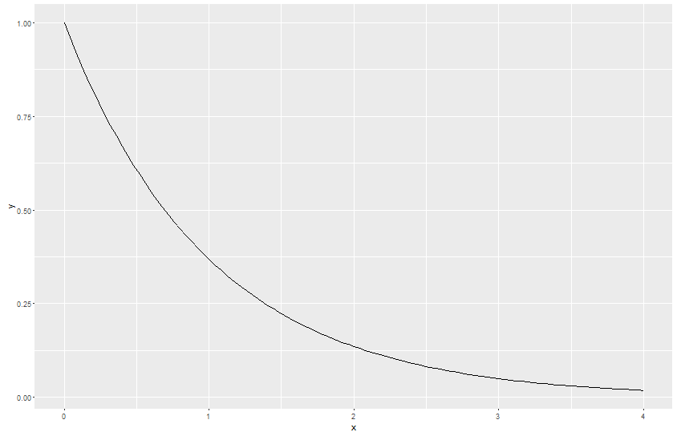

$\beta = \frac{1}{\lambda}$

**Mean**: $E[X] = \beta$

**Variance**: $Var[X] = \beta^2$

### R - Exponential

```r
pexp(q, rate = 1, lower.tail = TRUE, log.p = FALSE)   # probability according to quantile (cumulative)
qexp(p, rate = 1, lower.tail = TRUE, log.p = FALSE)   # quantile according to probability
rexp(n, rate = 1)                                     # random selection

# x = number, x
# q = quantile (x)
# p = probability
# n = number of observations
# rate = 1/lambda - beta
```

### Example

The arrival time of automobiles at the intersection of McFarland and 15th street follows an exponential distribution with a mean of 10 seconds.

1. What is the probability that the arrival time between cars at the intersection is 4 seconds or more?

```r
pexp(4, rate = 1/10, lower.tail = FALSE)
```

```
## [1] 0.67032
```

2. What is the probability that the arrival time between cars at the intersection is 8 seconds or less?

```r
pexp(8, rate = 1/10)
```

```
## [1] 0.550671
```

### Other Common Continuous Probability Distributions

1. Gamma
2. Beta
3. Weibull
4. F
5. t
6. Chi-squared